# model stability plots, cross validation

SID: 490300286

11 November, 2021

# creating final dataset

```r
# selecting macros
foods = tech_nutr %>% dplyr::select(ABSPID,
                             VEGLEG1N,
                             VEGLEG2N,
                              FRUIT1N,
                              FRUIT2N,
                              DAIRY1N,
                              DAIRY2N,
                              MEAT1N,
                              MEAT2N,
                              GRAINS1N,
                              GRAINS2N)


# gettin average of macros
avg_veges <- rowMeans(foods[ , c(2,3)], na.rm=TRUE)
avg_fruit <- rowMeans(foods[ , c(4,5)], na.rm=TRUE)
avg_dairy <- rowMeans(foods[ , c(6,7)], na.rm=TRUE)
avg_meat <- rowMeans(foods[ , c(8,9)], na.rm=TRUE)
avg_grains <- rowMeans(foods[ , c(10,11)], na.rm=TRUE)


dat <- cbind(tech_nutr$ABSPID,
             avg_veges,
             avg_fruit,
             avg_dairy,
             avg_meat,
             avg_grains)

dat <- as_tibble(dat)
colnames(dat)[1] <- "ABSPID"

dat$avg_veges <- as.numeric(dat$avg_veges)
dat$avg_fruit <- as.numeric(dat$avg_fruit)
dat$avg_dairy <- as.numeric(dat$avg_dairy)
dat$avg_meat <- as.numeric(dat$avg_meat)
dat$avg_grains <- as.numeric(dat$avg_grains)



tech_biom1 = tech_biom %>% dplyr::select(c(1:53))

final = merge(dat, tech_biom1, by = "ABSPID")
final = final %>% dplyr::select(avg_veges,
                         avg_fruit,
                         avg_dairy,
                         avg_meat,
                         avg_grains,
                         BMISC,
                         AGEC,
                         SEX,
                         PHDKGWBC,
                         PHDCMHBC,
                         PHDCMWBC,
                         SF2SA1QN)


final$w2hratio = (final$PHDCMWBC)/(final$PHDCMHBC)

# to make results more robust, focus on adults only

final <- final %>% filter(AGEC > 17)

final = final %>% na.omit()
```

The code in this code chunk just makes a final data frame with the avg servings of each food group for each participant

# short analysis

## linear regression with BMI as outcome

```r
bmi_full <- lm(BMISC ~ avg_veges + avg_fruit + avg_dairy + avg_meat + avg_grains + AGEC + SEX, dat = final)
bmi_null <- lm(BMISC ~ 1, dat = final)
```

## linear regression with waist to heigh ratio as outcome

```r
w2hratio_full <- lm(w2hratio ~ avg_veges + avg_fruit + avg_dairy + avg_meat + avg_grains + AGEC + SEX, dat = final)
w2hratio_null <- lm(w2hratio ~ 1, dat = final)
```

## linear regression with waist circumference as outcome

```r
waist_full <- lm(PHDCMWBC ~ avg_veges + avg_fruit + avg_dairy + avg_meat + avg_grains + AGEC + SEX, dat = final)
waist_null <- lm(PHDCMWBC ~ 1, dat = final)
```

NOTE: robust regression was attempted and gave similar results to OLS, so just using OLS instead.

## table of all models

```r
full_model_table <- tab_model(bmi_full, waist_full, w2hratio_full, show.ci = F, show.se = T)
full_model_table
```

|  | BMISC |  |  | PHDCMWBC |  |  | w 2 hratio |  |  |
| --- | --- | --- | --- | --- | --- | --- | --- | --- | --- |
| Predictors | Estimates | std. Error | p | Estimates | std. Error | p | Estimates | std. Error | p |
| (Intercept) | 25.98 | 0.24 | **<0.001** | 89.07 | 0.59 | **<0.001** | 0.49 | 0.00 | **<0.001** |
| avg veges | -0.12 | 0.03 | **<0.001** | -0.29 | 0.08 | **<0.001** | -0.00 | 0.00 | **<0.001** |
| avg fruit | -0.20 | 0.05 | **<0.001** | -0.57 | 0.11 | **<0.001** | -0.00 | 0.00 | **<0.001** |
| avg dairy | 0.10 | 0.07 | 0.141 | 0.18 | 0.16 | 0.255 | -0.00 | 0.00 | 0.275 |
| avg meat | 0.22 | 0.05 | **<0.001** | 0.37 | 0.12 | **0.002** | 0.00 | 0.00 | **0.007** |
| avg grains | -0.17 | 0.03 | **<0.001** | -0.38 | 0.07 | **<0.001** | -0.00 | 0.00 | **<0.001** |
| AGEC | 0.05 | 0.00 | **<0.001** | 0.23 | 0.01 | **<0.001** | 0.00 | 0.00 | **<0.001** |
| SEX [2] | -0.66 | 0.13 | **<0.001** | -10.08 | 0.31 | **<0.001** | -0.02 | 0.00 | **<0.001** |
| Observations | 7811 |  |  | 7811 |  |  | 7811 |  |  |
| R<sup>2</sup> / R<sup>2</sup> adjusted | 0.041 / 0.040 |  |  | 0.190 / 0.190 |  |  | 0.155 / 0.154 |  |  |

dairy is insignificant for all

## Model selection and performance (10 fold CV)

Model selection using backward and forward selection

### BMI

```r
n = nrow(final)

# bmi_AIC is just full model
# bmi_AIC <- step(bmi_full, direction = "backward", trace = F)

bmi_BIC <- step(bmi_full, direction = "backward", trace = F, k = log(n))

bmi_BIC %>% summary()
```

```
##
## Call:
## lm(formula = BMISC ~ avg_veges + avg_fruit + avg_meat + avg_grains +
##     AGEC + SEX, data = final)
##
## Residuals:
##     Min      1Q  Median      3Q     Max
## -13.874  -3.789  -0.853   2.792  35.303
##
## Coefficients:
##              Estimate Std. Error t value Pr(>|t|)
## (Intercept) 26.045003   0.238718 109.104  < 2e-16 ***
## avg_veges   -0.122044   0.032690  -3.733  0.00019 ***
## avg_fruit   -0.193050   0.046365  -4.164 3.17e-05 ***
## avg_meat     0.217007   0.049437   4.390 1.15e-05 ***
## avg_grains  -0.163914   0.027350  -5.993 2.15e-09 ***
## AGEC         0.053754   0.003591  14.970  < 2e-16 ***
## SEX2        -0.663499   0.127672  -5.197 2.08e-07 ***
## ---
## Signif. codes:  0 '***' 0.001 '**' 0.01 '*' 0.05 '.' 0.1 ' ' 1
##
## Residual standard error: 5.445 on 7804 degrees of freedom
## Multiple R-squared:  0.041,  Adjusted R-squared:  0.04027
## F-statistic: 55.61 on 6 and 7804 DF,  p-value: < 2.2e-16
```

```r
# fwd AIC model same as back
# step(bmi_null, scope = list(lower = bmi_null, upper = bmi_full), direction = "forward", trace = F)
```

### waist circumeference

```r
waist_AIC <- step(waist_full, direction = "backward", trace = F)

# waist_BIC same as AIC
# waist_BIC <- step(waist_full, direction = "backward", trace = F, k = log(n))

waist_AIC %>% summary()
```

```
##
## Call:
## lm(formula = PHDCMWBC ~ avg_veges + avg_fruit + avg_meat + avg_grains +
##     AGEC + SEX, data = final)
##
## Residuals:
##     Min      1Q  Median      3Q     Max
## -51.529  -9.403  -1.406   7.810  54.381
##
## Coefficients:
##               Estimate Std. Error t value Pr(>|t|)
## (Intercept)  89.200875   0.580130 153.760  < 2e-16 ***
## avg_veges    -0.281835   0.079444  -3.548 0.000391 ***
## avg_fruit    -0.560373   0.112676  -4.973 6.72e-07 ***
## avg_meat      0.368521   0.120142   3.067 0.002167 **
## avg_grains   -0.355198   0.066465  -5.344 9.34e-08 ***
## AGEC          0.234240   0.008726  26.843  < 2e-16 ***
## SEX2        -10.083931   0.310266 -32.501  < 2e-16 ***
## ---
## Signif. codes:  0 '***' 0.001 '**' 0.01 '*' 0.05 '.' 0.1 ' ' 1
##
## Residual standard error: 13.23 on 7804 degrees of freedom
## Multiple R-squared:  0.1902, Adjusted R-squared:  0.1896
## F-statistic: 305.5 on 6 and 7804 DF,  p-value: < 2.2e-16
```

```r
# backward selection same as fwd
# step(waist_null, scope = list(lower = waist_null, upper = waist_full), direction = "forward", trace = F)
```

### w2h ratio

```r
w2hratio_AIC <- step(w2hratio_full, direction = "backward", trace = F)
w2hratio_BIC <- step(w2hratio_full, direction = "backward", trace = F, k = log(n))

w2hratio_AIC %>% summary()
```

```
##
## Call:
## lm(formula = w2hratio ~ avg_veges + avg_fruit + avg_meat + avg_grains +
##     AGEC + SEX, data = final)
##
## Residuals:
##      Min       1Q   Median       3Q      Max
## -0.29127 -0.05698 -0.00884  0.04519  0.37237
##
## Coefficients:
##               Estimate Std. Error t value Pr(>|t|)
## (Intercept)  0.4864490  0.0034838 139.633  < 2e-16 ***
## avg_veges   -0.0021829  0.0004771  -4.576 4.82e-06 ***
## avg_fruit   -0.0043052  0.0006766  -6.363 2.09e-10 ***
## avg_meat     0.0019355  0.0007215   2.683  0.00732 **
## avg_grains  -0.0020220  0.0003991  -5.066 4.16e-07 ***
## AGEC         0.0018685  0.0000524  35.657  < 2e-16 ***
## SEX2        -0.0155878  0.0018632  -8.366  < 2e-16 ***
## ---
## Signif. codes:  0 '***' 0.001 '**' 0.01 '*' 0.05 '.' 0.1 ' ' 1
##
## Residual standard error: 0.07947 on 7804 degrees of freedom
## Multiple R-squared:  0.1547, Adjusted R-squared:  0.154
## F-statistic:   238 on 6 and 7804 DF,  p-value: < 2.2e-16
```

```r
w2hratio_BIC %>% summary()
```

```
##
## Call:
## lm(formula = w2hratio ~ avg_veges + avg_fruit + avg_grains +
##     AGEC + SEX, data = final)
##
## Residuals:
##      Min       1Q   Median       3Q      Max
## -0.29282 -0.05662 -0.00879  0.04512  0.37038
##
## Coefficients:
##               Estimate Std. Error t value Pr(>|t|)
## (Intercept)  4.892e-01  3.330e-03 146.910  < 2e-16 ***
## avg_veges   -1.759e-03  4.503e-04  -3.906 9.46e-05 ***
## avg_fruit   -4.146e-03  6.743e-04  -6.149 8.18e-10 ***
## avg_grains  -1.908e-03  3.970e-04  -4.806 1.57e-06 ***
## AGEC         1.858e-03  5.229e-05  35.542  < 2e-16 ***
## SEX2        -1.644e-02  1.837e-03  -8.948  < 2e-16 ***
## ---
## Signif. codes:  0 '***' 0.001 '**' 0.01 '*' 0.05 '.' 0.1 ' ' 1
##
## Residual standard error: 0.0795 on 7805 degrees of freedom
## Multiple R-squared:  0.1539, Adjusted R-squared:  0.1533
## F-statistic: 283.9 on 5 and 7805 DF,  p-value: < 2.2e-16
```

```r
# backward selection same as fwd
# step(w2hratio_null, scope = list(lower = w2hratio_null, upper = waist_full), direction = "forward", trace = F)
```

# model stability plots

```r
vis.obj_bmi <- vis(bmi_full, B = 150, redundant = TRUE, nbest = "all",
               seed = 2021)
vis.obj_waist <- vis(waist_full, B = 150, redundant = TRUE, nbest = "all",
               seed = 2021)
vis.obj_w2hratio <- vis(w2hratio_full, B = 150, redundant = TRUE, nbest = "all",
               seed = 2021)
```

## BMI

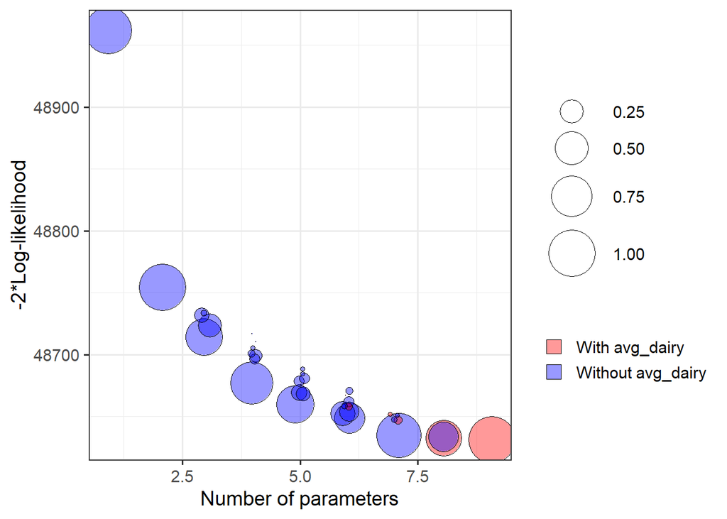

```r
plot(vis.obj_bmi,
     interactive = FALSE,
     highlight = "avg_dairy",
     which = "boot")
```

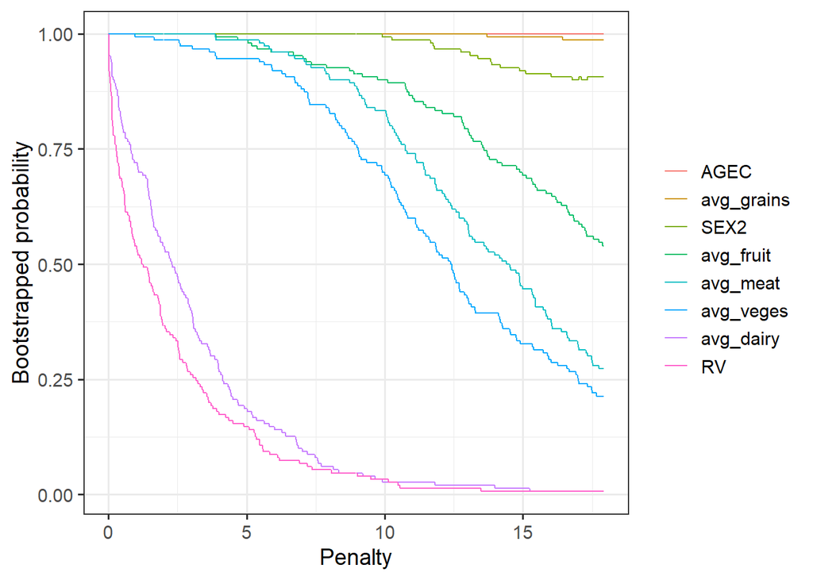

```r
plot(vis.obj_bmi,
     interactive = FALSE,
     highlight = "avg_dairy",
     which = "vip")
```

Shows that dairy is close to the Redundant variable (RV) curve, hence dairy does not add any significant information to the model.

# w2h ratio

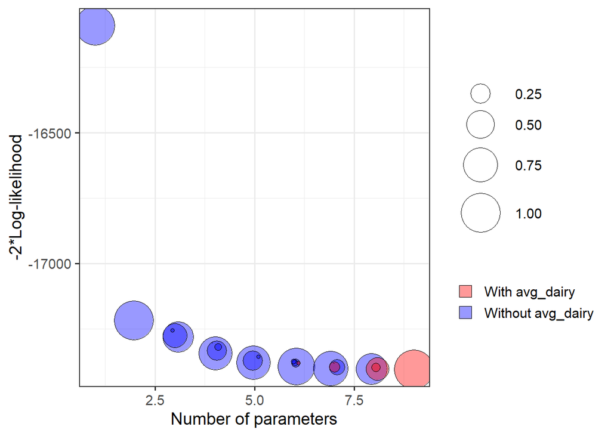

```r
plot(vis.obj_w2hratio,
     interactive = FALSE,
     highlight = "avg_dairy",
     which = "boot")
```

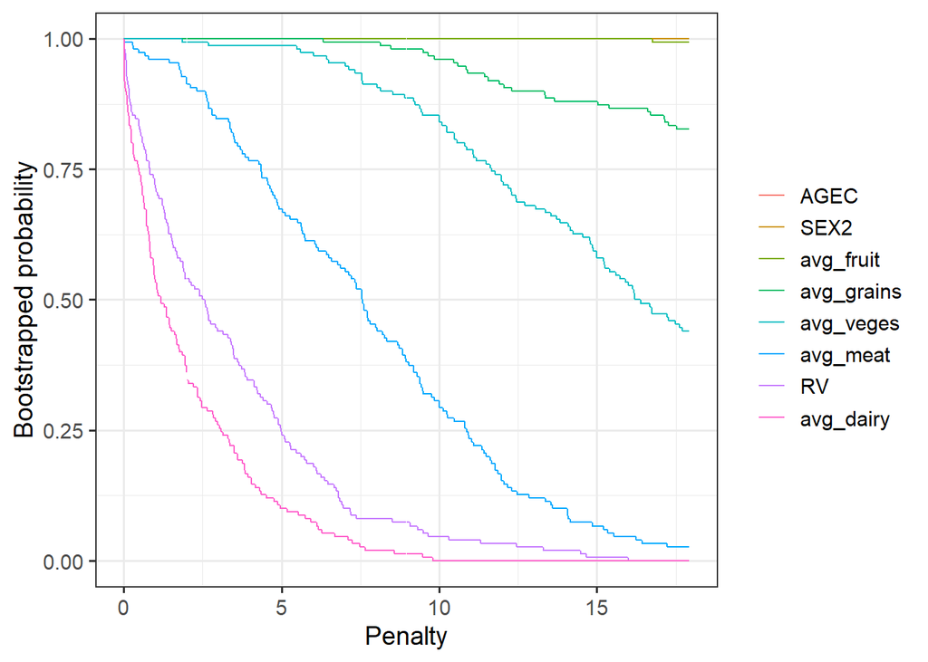

```r
plot(vis.obj_w2hratio,
     interactive = FALSE,
     highlight = "avg_dairy",
     which = "vip")
```

Shows that dairy is close to the Redundant variable (RV) curve, hence dairy does not add any significant information to the model.

# waist circumference

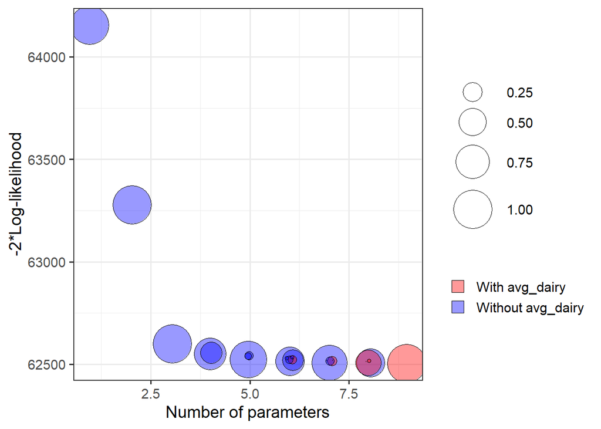

```r
plot(vis.obj_waist,
     interactive = FALSE,
     highlight = "avg_dairy",
     which = "boot")
```

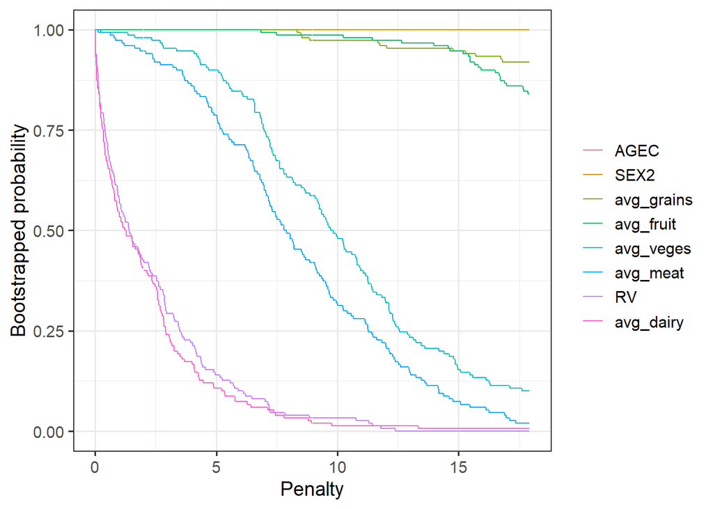

```r
plot(vis.obj_waist,
     interactive = FALSE,
     highlight = "avg_dairy",
     which = "vip")
```

Shows that dairy is close to the Redundant variable (RV) curve, hence dairy does not add any significant information to the model.

From all of these above plots, we can see that models containing `avg_dairy` are only dominant when there are a large number of parameters in the model (i.e. close to the full model). From this, we can see that avg_dairy is not particularly stable, and therefore suggests it should not be included in a final model.

# ANOVA of models

## BMI

```r
anova(bmi_BIC, bmi_full)
```

```
## Analysis of Variance Table
##
## Model 1: BMISC ~ avg_veges + avg_fruit + avg_meat + avg_grains + AGEC +
##     SEX
## Model 2: BMISC ~ avg_veges + avg_fruit + avg_dairy + avg_meat + avg_grains +
##     AGEC + SEX
##   Res.Df    RSS Df Sum of Sq      F Pr(>F)
## 1   7804 231389
## 2   7803 231325  1    64.253 2.1674  0.141
```

From this, we can see that when we can see that p = 0.141 > 0.05 when dairy is added as a covariate. Hence it should not be included in the final model.

## Waist circumference

```r
anova(waist_AIC, waist_full)
```

```
## Analysis of Variance Table
##
## Model 1: PHDCMWBC ~ avg_veges + avg_fruit + avg_meat + avg_grains + AGEC +
##     SEX
## Model 2: PHDCMWBC ~ avg_veges + avg_fruit + avg_dairy + avg_meat + avg_grains +
##     AGEC + SEX
##   Res.Df     RSS Df Sum of Sq      F Pr(>F)
## 1   7804 1366547
## 2   7803 1366320  1    227.03 1.2966 0.2549
```

From the above ANOVA, p > 0.05, hence model with dairy is insignificant so final model should exlcude dairy

```r
anova(w2hratio_BIC, w2hratio_AIC, w2hratio_full)
```

```
## Analysis of Variance Table
##
## Model 1: w2hratio ~ avg_veges + avg_fruit + avg_grains + AGEC + SEX
## Model 2: w2hratio ~ avg_veges + avg_fruit + avg_meat + avg_grains + AGEC +
##     SEX
## Model 3: w2hratio ~ avg_veges + avg_fruit + avg_dairy + avg_meat + avg_grains +
##     AGEC + SEX
##   Res.Df    RSS Df Sum of Sq      F   Pr(>F)
## 1   7805 49.326
## 2   7804 49.280  1  0.045449 7.1974 0.007316 **
## 3   7803 49.273  1  0.007527 1.1920 0.274962
## ---
## Signif. codes:  0 '***' 0.001 '**' 0.01 '*' 0.05 '.' 0.1 ' ' 1
```

```r
anova(w2hratio_BIC, w2hratio_AIC, w2hratio_full)
```

```
## Analysis of Variance Table
##
## Model 1: w2hratio ~ avg_veges + avg_fruit + avg_grains + AGEC + SEX
## Model 2: w2hratio ~ avg_veges + avg_fruit + avg_meat + avg_grains + AGEC +
##     SEX
## Model 3: w2hratio ~ avg_veges + avg_fruit + avg_dairy + avg_meat + avg_grains +
##     AGEC + SEX
##   Res.Df    RSS Df Sum of Sq      F   Pr(>F)
## 1   7805 49.326
## 2   7804 49.280  1  0.045449 7.1974 0.007316 **
## 3   7803 49.273  1  0.007527 1.1920 0.274962
## ---
## Signif. codes:  0 '***' 0.001 '**' 0.01 '*' 0.05 '.' 0.1 ' ' 1
```

The BIC is nested within the AIC model which is nested within the full model. From the output, the ANOVA table shows p < 0.05 for the AIC model only. Hence all food groups except dairy are significant.

# Cross validation

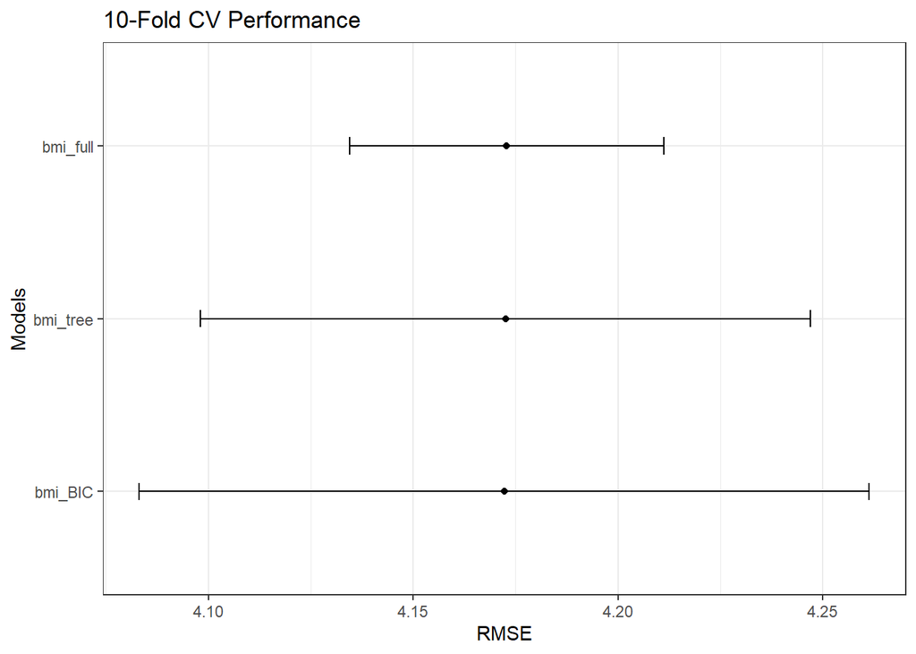

```r
params = trainControl(method = "cv", number = 10, verboseIter = FALSE)

set.seed(2021)

cv_objects = list(
  bmi_full = train(BMISC ~ avg_veges + avg_fruit + avg_dairy + avg_meat +
    avg_grains + AGEC + SEX,
    method = "lm",
    data = final,
    trControl = params),
  bmi_BIC = train(BMISC ~ avg_veges + avg_fruit + avg_meat + avg_grains +
    AGEC + SEX,
    method = "lm",
    data = final,
    trControl = params),
    bmi_tree = train(BMISC ~ avg_veges + avg_fruit + avg_dairy + avg_meat + avg_grains + AGEC + SEX,
                   data = final,
                   method = 'rpart',
                   tuneLength  = 15,
                   trControl = params),
  waist_full = train(PHDCMWBC ~ avg_veges + avg_fruit + avg_dairy + avg_meat + avg_grains + AGEC + SEX,
    method = "lm",
    data = final,
    trControl = params),
  waist_AIC = train(PHDCMWBC ~ avg_veges + avg_fruit + avg_meat + avg_grains + AGEC + SEX,
    method = "lm",
    data = final,
    trControl = params),
  waist_tree = train(PHDCMWBC ~ avg_veges + avg_fruit + avg_dairy + avg_meat + avg_grains + AGEC + SEX,
                   data = final,
                   method = 'rpart',
                   tuneLength  = 15,
                   trControl = params),
  w2hratio_full = train(w2hratio ~ avg_veges + avg_fruit + avg_dairy + avg_meat + avg_grains + AGEC + SEX,
    method = "lm",
    data = final,
    trControl = params),
  w2hratio_AIC = train(w2hratio ~ avg_veges + avg_fruit + avg_meat + avg_grains + AGEC + SEX,
    method = "lm",
    data = final,
    trControl = params),
  w2hratio_BIC = train(w2hratio ~ avg_veges + avg_fruit + avg_grains +
    AGEC + SEX,
    method = "lm",
    data = final,
    trControl = params),
  w2hratio_tree = train(w2hratio ~ avg_veges + avg_fruit + avg_dairy + avg_meat + avg_grains + AGEC + SEX,
                   data = final,
                   method = 'rpart',
                   tuneLength  = 15,
                   trControl = params)
)

cv_results_bmi = resamples(cv_objects[1:3], metric = "RMSE")
ggplot(cv_results_bmi) +
  theme_bw() +
  labs(x = "Models", y = "RMSE", title = "10-Fold CV Performance")
```

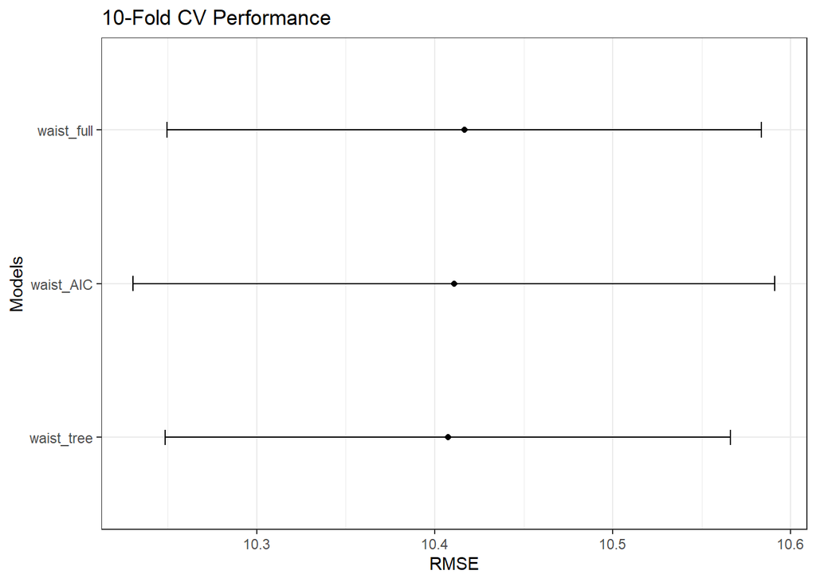

```r
cv_results_waist = resamples(cv_objects[4:6], metric = "RMSE")
ggplot(cv_results_waist) +
  theme_bw() +
  labs(x = "Models", y = "RMSE", title = "10-Fold CV Performance")
```

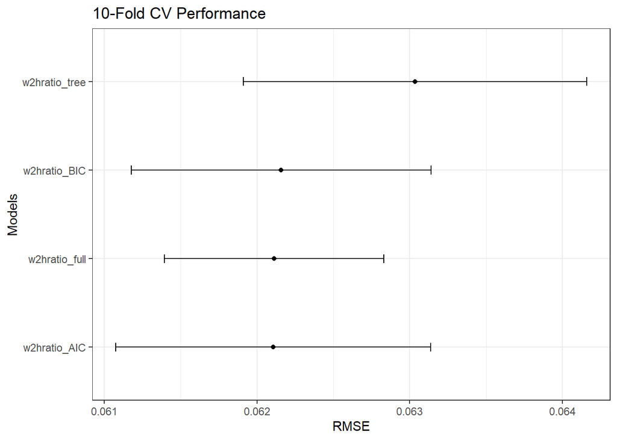

```r
cv_results_w2hratio = resamples(cv_objects[7:10], metric = "RMSE")
ggplot(cv_results_w2hratio) +
  theme_bw() +
  labs(x = "Models", y = "RMSE", title = "10-Fold CV Performance")
```

## comaring standardized betas

```r
# creating scaled df
sex <- final$SEX
socioeconomic <- final$SF2SA1QN
scaled_df <- final %>%
  dplyr::select(-c(SEX, SF2SA1QN)) %>%
  scale() %>% as.data.frame()


scaled_df$SEX <- sex
scaled_df$SF2SA1QN <- socioeconomic

# lm scaled to get standardized betas to compare
bmi_scaled <- lm(BMISC ~ avg_veges + avg_fruit + avg_dairy + avg_meat + avg_grains + AGEC + SEX, dat = scaled_df)
w2h_scaled <- lm(w2hratio ~ avg_veges + avg_fruit + avg_dairy + avg_meat + avg_grains + AGEC + SEX, dat = scaled_df)
waist_scaled <- lm(PHDCMWBC ~ avg_veges + avg_fruit + avg_dairy + avg_meat + avg_grains + AGEC + SEX, dat = scaled_df)
```

```r
st_beta_table <- tab_model(bmi_scaled, w2h_scaled, waist_scaled)
st_beta_table
```

|  | BMISC |  |  | w 2 hratio |  |  | PHDCMWBC |  |  |
| --- | --- | --- | --- | --- | --- | --- | --- | --- | --- |
| Predictors | Estimates | CI | p | Estimates | CI | p | Estimates | CI | p |
| (Intercept) | 0.06 | 0.03 – 0.09 | **<0.001** | 0.09 | 0.06 – 0.12 | **<0.001** | 0.36 | 0.33 – 0.39 | **<0.001** |
| avg veges | -0.05 | -0.07 – -0.02 | **<0.001** | -0.05 | -0.07 – -0.03 | **<0.001** | -0.04 | -0.06 – -0.02 | **<0.001** |
| avg fruit | -0.05 | -0.07 – -0.03 | **<0.001** | -0.07 | -0.09 – -0.05 | **<0.001** | -0.05 | -0.07 – -0.03 | **<0.001** |
| avg dairy | 0.02 | -0.01 – 0.04 | 0.141 | -0.01 | -0.03 – 0.01 | 0.275 | 0.01 | -0.01 – 0.03 | 0.255 |
| avg meat | 0.05 | 0.03 – 0.08 | **<0.001** | 0.03 | 0.01 – 0.05 | **0.007** | 0.03 | 0.01 – 0.06 | **0.002** |
| avg grains | -0.08 | -0.10 – -0.05 | **<0.001** | -0.05 | -0.08 – -0.03 | **<0.001** | -0.06 | -0.09 – -0.04 | **<0.001** |
| AGEC | 0.17 | 0.15 – 0.19 | **<0.001** | 0.38 | 0.36 – 0.40 | **<0.001** | 0.28 | 0.26 – 0.30 | **<0.001** |
| SEX [2] | -0.12 | -0.16 – -0.07 | **<0.001** | -0.18 | -0.22 – -0.14 | **<0.001** | -0.69 | -0.73 – -0.64 | **<0.001** |
| Observations | 7811 |  |  | 7811 |  |  | 7811 |  |  |
| R<sup>2</sup> / R<sup>2</sup> adjusted | 0.041 / 0.040 |  |  | 0.155 / 0.154 |  |  | 0.190 / 0.190 |  |  |